# Project 2: Data Mining, Classification, Prediction

SDS322E

# Mining, Classification, Prediction

## Ana Santiago, ass2325

### Introduction

I am using the ‘Heart’ data set which I found on kaggle for my project. This data set is used to predict heart failure in different gender and ages based on a variety of measurements. The main categorical variable that I will be using in this project is ‘Sex’. The main numerical variables that I will be using are ‘Age’, ‘Resting BP’ (resting blood pressure), ‘Cholesterol’, ‘Max HR’(maximum heart rate), ‘Oldpeak’ (value of exercise relative to rest, slope), and ‘Heart Disease’. Each of these variables measure information about the patient’s medical history in order to predict whether they are susceptible to heart failure. The binary variable I will be using is ‘Heart Disease’ in which a value of 1 indicates heart disease in the patient and a value of 0 indicates no heart disease. In the entire data set, there is a total of 918 observations. Grouping by ‘Sex’, there are 193 female and 725 male observations. Grouping by ‘Heart Disease’, there are 410 individuals with no heart disease and 508 individuals with heart disease.

```r
library(tidyverse)
# read your datasets in here, e.g., with read_csv()
library(dplyr)
library(cluster)
library(ggplot2)

heart <- read_csv("~/project2/heart.csv")
heart.df <- as.data.frame(heart)
sum(is.na(heart.df))
```

```
## [1] 0
```

```r
na.omit(heart.df)
```

```
##   Age Sex ChestPainType RestingBP Cholesterol FastingBS RestingECG MaxHR
## 1  40   M           ATA       140         289         0     Normal   172
## 2  49   F           NAP       160         180         0     Normal   156
## 3  37   M           ATA       130         283         0         ST    98
## 4  48   F           ASY       138         214         0     Normal   108
## 5  54   M           NAP       150         195         0     Normal   122
## 6  39   M           NAP       120         339         0     Normal   170
## 7  45   F           ATA       130         237         0     Normal   170
## 8  54   M           ATA       110         208         0     Normal   142
##   ExerciseAngina Oldpeak ST_Slope HeartDisease
## 1              N     0.0       Up            0
## 2              N     1.0     Flat            1
## 3              N     0.0       Up            0
## 4              Y     1.5     Flat            1
## 5              N     0.0       Up            0
## 6              N     0.0       Up            0
## 7              N     0.0       Up            0
## 8              N     0.0       Up            0
##  [ reached 'max' / getOption("max.print") -- omitted 910 rows ]
```

```r
head(heart.df)
```

```
##   Age Sex ChestPainType RestingBP Cholesterol FastingBS RestingECG MaxHR
## 1  40   M           ATA       140         289         0     Normal   172
## 2  49   F           NAP       160         180         0     Normal   156
## 3  37   M           ATA       130         283         0         ST    98
## 4  48   F           ASY       138         214         0     Normal   108
## 5  54   M           NAP       150         195         0     Normal   122
## 6  39   M           NAP       120         339         0     Normal   170
##   ExerciseAngina Oldpeak ST_Slope HeartDisease
## 1              N     0.0       Up            0
## 2              N     1.0     Flat            1
## 3              N     0.0       Up            0
## 4              Y     1.5     Flat            1
## 5              N     0.0       Up            0
## 6              N     0.0       Up            0
```

```r
# if your dataset needs tidying, do so here
heartnumeric <- heart.df %>% select(Age, RestingBP, Cholesterol,
    MaxHR, Oldpeak)
heartn <- as.data.frame(scale(heartnumeric))
# any other code here
str(heart.df)
```

```
## 'data.frame':    918 obs. of  12 variables:
##  $ Age           : num  40 49 37 48 54 39 45 54 37 48 ...
##  $ Sex           : chr  "M" "F" "M" "F" ...
##  $ ChestPainType : chr  "ATA" "NAP" "ATA" "ASY" ...
##  $ RestingBP     : num  140 160 130 138 150 120 130 110 140 120 ...
##  $ Cholesterol   : num  289 180 283 214 195 339 237 208 207 284 ...
##  $ FastingBS     : num  0 0 0 0 0 0 0 0 0 0 ...
##  $ RestingECG    : chr  "Normal" "Normal" "ST" "Normal" ...
##  $ MaxHR         : num  172 156 98 108 122 170 170 142 130 120 ...
##  $ ExerciseAngina: chr  "N" "N" "N" "Y" ...
##  $ Oldpeak       : num  0 1 0 1.5 0 0 0 0 1.5 0 ...
##  $ ST_Slope      : chr  "Up" "Flat" "Up" "Flat" ...
##  $ HeartDisease  : num  0 1 0 1 0 0 0 0 1 0 ...
##  - attr(*, "spec")=
##   .. cols(
##   ..   Age = col_double(),
##   ..   Sex = col_character(),
##   ..   ChestPainType = col_character(),
##   ..   RestingBP = col_double(),
##   ..   Cholesterol = col_double(),
##   ..   FastingBS = col_double(),
##   ..   RestingECG = col_character(),
##   ..   MaxHR = col_double(),
##   ..   ExerciseAngina = col_character(),
##   ..   Oldpeak = col_double(),
##   ..   ST_Slope = col_character(),
##   ..   HeartDisease = col_double()
##   .. )
```

```r
# counting observations
nrow(heart.df)
```

```
## [1] 918
```

```r
heart.df %>% summarise_all(n_distinct)
```

```
##   Age Sex ChestPainType RestingBP Cholesterol FastingBS RestingECG MaxHR
## 1  50   2             4        67         222         2          3   119
##   ExerciseAngina Oldpeak ST_Slope HeartDisease
## 1              2      53        3            2
```

```r
heart.df %>% count(Sex)
```

```
##   Sex   n
## 1   F 193
## 2   M 725
```

```r
heart.df %>% count(HeartDisease)
```

```
##   HeartDisease   n
## 1            0 410
## 2            1 508
```

### Cluster Analysis

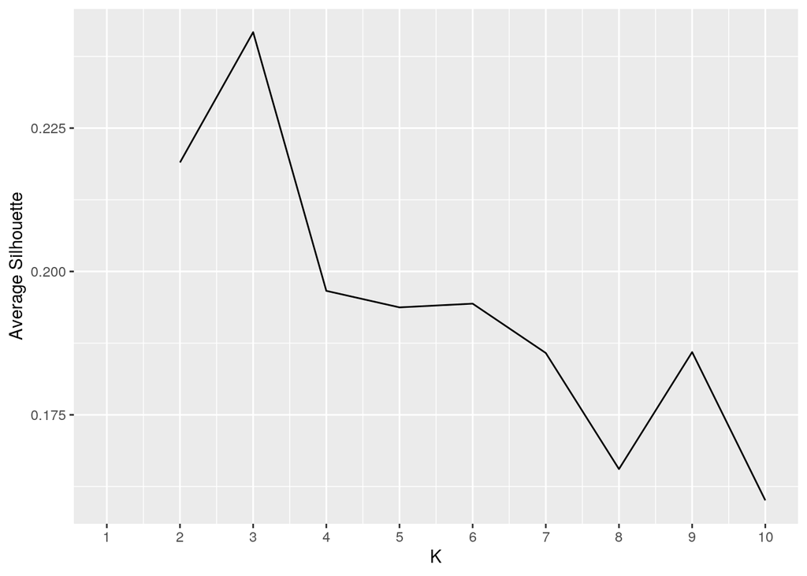

```r
library(cluster)
library(GGally)
# clustering code here Silhouette Method to find kmeans
sil_width <- vector()
for (i in 2:10) {
    kms <- kmeans(heartn, centers = i)
    sil <- silhouette(kms$cluster, dist(heartn))
    sil_width[i] <- mean(sil[, 3])
}
ggplot() + geom_line(aes(x = 1:10, y = sil_width)) + scale_x_continuous(name = "K",
    breaks = 1:10) + ylab("Average Silhouette")
```

```r
# Average Silhouette Width
heart_pam <- heartn %>% pam(k = 3)
heart_pam$silinfo$avg.width
```

```
## [1] 0.2343296
```

```r
# PAM analysis
pam1 <- heart.df %>% pam(k = 3)
pam1
```

```
## Medoids:
##       ID Age Sex ChestPainType RestingBP Cholesterol FastingBS RestingECG MaxHR
## [1,] 238  55  NA            NA       140         295         0         NA   136
## [2,] 477  51  NA            NA       132         218         1         NA   139
## [3,] 536  56  NA            NA       130           0         0         NA   122
##      ExerciseAngina Oldpeak ST_Slope HeartDisease
## [1,]             NA     0.0       NA            1
## [2,]             NA     0.1       NA            0
## [3,]             NA     1.0       NA            1
## Clustering vector:
##   [1] 1 2 1 2 2 1 2 2 2 1 2 2 2 2 2 1 2 2 2 1 2 2 2 1 2 2 1 1 1 2 1 2 2 2 2 2 1
##  [38] 2 2 2 2 1 1 1 2 1 2 2 1 1 2 2 2 2 2 2 1 2 1 1 2 2 2 1 2 1 1 2 2 1 1 2 2 2
##  [75] 1 2 1 2 3 2 1 2 2 2 2 2 1 2 1 2 2 1 2 1 2 1 2 2 3 1
##  [ reached getOption("max.print") -- omitted 818 entries ]
## Objective function:
##    build     swap
## 52.72061 52.72061
##
## Available components:
##  [1] "medoids"    "id.med"     "clustering" "objective"  "isolation"
##  [6] "clusinfo"   "silinfo"    "diss"       "call"       "data"
```

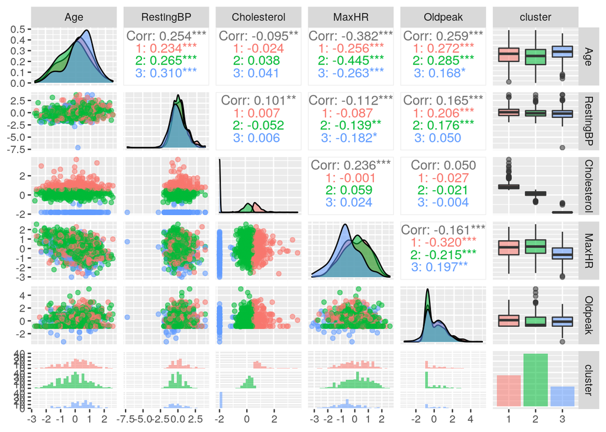

```r
heartn %>% mutate(cluster = as.factor(pam1$clustering)) %>% ggpairs(cols = c("Age",
    "RestingBP", "Cholesterol", "MaxHR", "Oldpeak"), aes(color = cluster,
    alpha = 0.5))
```

```r
pamclust <- heart.df %>% mutate(cluster = as.factor(pam1$clustering))
pamclust %>% group_by(cluster) %>% summarize_if(is.numeric, mean,
    na.rm = T)
```

```
## # A tibble: 3 x 8
##   cluster   Age RestingBP Cholesterol FastingBS MaxHR Oldpeak HeartDisease
##   <fct>   <dbl>     <dbl>       <dbl>     <dbl> <dbl>   <dbl>        <dbl>
## 1 1        53.9      136.      303.       0.188  138.   1.04         0.562
## 2 2        52.2      131.      212.       0.155  141.   0.823        0.427
## 3 3        56.3      130.        2.24     0.511  122.   0.824        0.875
```

```r
heart.df %>% slice(pam1$id.med)
```

```
##   Age Sex ChestPainType RestingBP Cholesterol FastingBS RestingECG MaxHR
## 1  55   M            TA       140         295         0     Normal   136
## 2  51   M           ASY       132         218         1        LVH   139
## 3  56   M           ASY       130           0         0        LVH   122
##   ExerciseAngina Oldpeak ST_Slope HeartDisease
## 1              N     0.0     Flat            1
## 2              N     0.1       Up            0
## 3              Y     1.0     Flat            1
```

To start clustering, I first used the Silhouette Method to produce a graph which shows that the optimal K and number of clusters is 3. I then calculated the Average Silhouette Width which came out to be 0.234, which is not as ideal of a structure as desired.

When summarizing the cluster by each group we can see the mean values within each cluster in order to best differentiate them from one another. Moreover, the best way to differentiate each cluster is through their ‘Cholesterol’ values; Cluster 1 having the highest cholesterol values with a mean of 302.67, Cluster 2 having middle cholesterol with a mean of 211.52, and Cluster 3 having a extremely low mean of 2.24.

### Dimensionality Reduction with PCA

```r
# PCA code here
library(factoextra)

keeps <- c("Age", "RestingBP", "Cholesterol", "MaxHR", "Oldpeak")
pcadf1 <- heart.df[keeps]

pca1 <- princomp(pcadf1, cor = T)
summary(pca1, loadings = T)
```

```
## Importance of components:
##                           Comp.1    Comp.2    Comp.3    Comp.4    Comp.5
## Standard deviation     1.3065648 1.0926990 0.9117941 0.8314805 0.7590579
## Proportion of Variance 0.3414223 0.2387982 0.1662737 0.1382719 0.1152338
## Cumulative Proportion  0.3414223 0.5802205 0.7464943 0.8847662 1.0000000
##
## Loadings:
##             Comp.1 Comp.2 Comp.3 Comp.4 Comp.5
## Age          0.603                0.317  0.728
## RestingBP    0.374  0.474  0.642 -0.430 -0.195
## Cholesterol -0.178  0.743         0.628 -0.129
## MaxHR       -0.539  0.344        -0.433  0.634
## Oldpeak      0.418  0.323 -0.759 -0.364 -0.113
```

```r
pca1$scores %>% cor %>% round(10)
```

```
##        Comp.1 Comp.2 Comp.3 Comp.4 Comp.5
## Comp.1      1      0      0      0      0
## Comp.2      0      1      0      0      0
## Comp.3      0      0      1      0      0
## Comp.4      0      0      0      1      0
## Comp.5      0      0      0      0      1
```

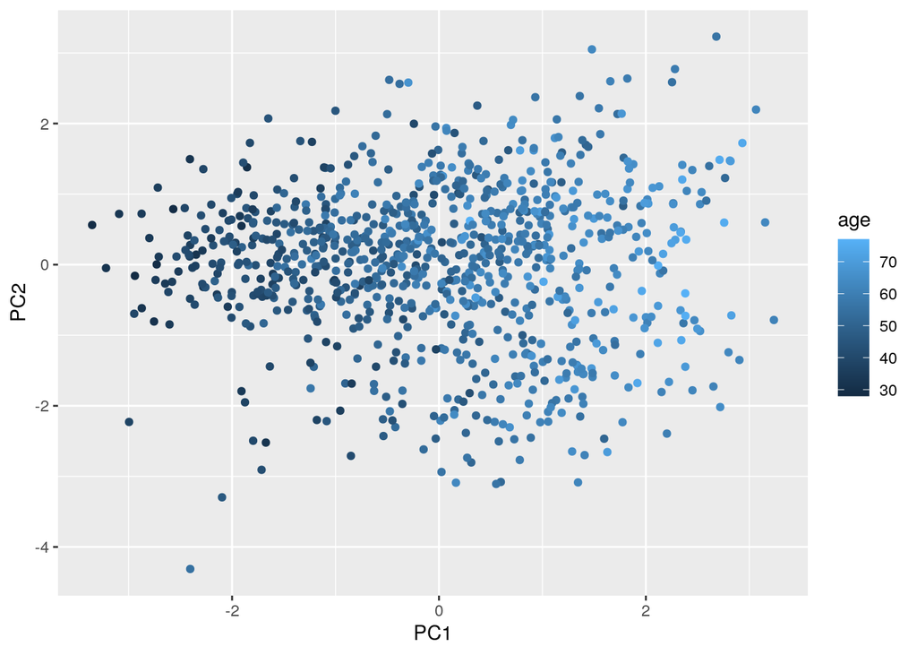

```r
pca1_df <- data.frame(PC1 = pca1$scores[, 1], PC2 = pca1$scores[,
    2])
pca1_df <- pca1_df %>% mutate(age = pcadf1$Age)

# Random PC Plot
ggplot(pca1_df, aes(PC1, PC2)) + geom_point(aes(color = age))
```

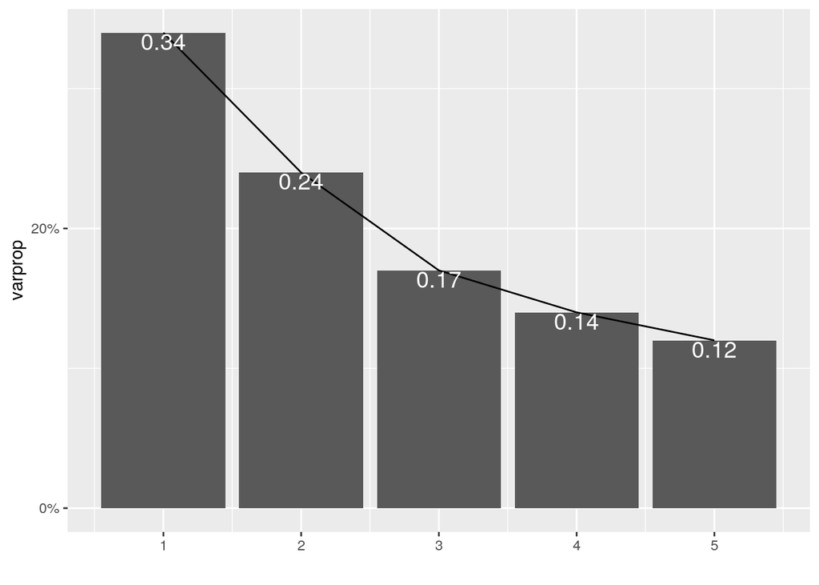

```r
# how many PCs to keep
eigval <- pca1$sdev^2
varprop = round(eigval/sum(eigval), 2)
ggplot() + geom_bar(aes(y = varprop, x = 1:5), stat = "identity") +
    xlab("") + geom_path(aes(y = varprop, x = 1:5)) + geom_text(aes(x = 1:5,
    y = varprop, label = round(varprop, 2)), vjust = 1, col = "white",
    size = 5) + scale_y_continuous(breaks = seq(0, 0.6, 0.2),
    labels = scales::percent) + scale_x_continuous(breaks = 1:10)
```

```r
round(cumsum(eigval)/sum(eigval), 2)
```

```
## Comp.1 Comp.2 Comp.3 Comp.4 Comp.5
##   0.34   0.58   0.75   0.88   1.00
```

```r
eigval
```

```
##    Comp.1    Comp.2    Comp.3    Comp.4    Comp.5
## 1.7071116 1.1939912 0.8313686 0.6913597 0.5761690
```

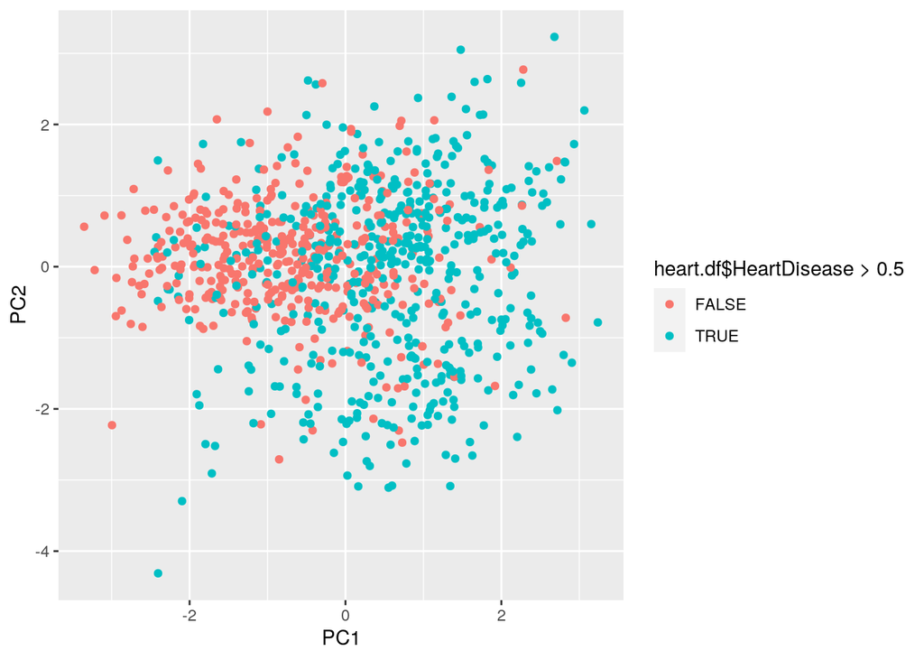

```r
# plotting PC scores kept
pcaplot <- data.frame(Name = heart.df$HeartDisease, PC1 = pca1$scores[,
    1], PC2 = pca1$scores[, 2])
ggplot(pcaplot, aes(PC1, PC2)) + geom_point(aes(color = heart.df$HeartDisease >
    0.5))
```

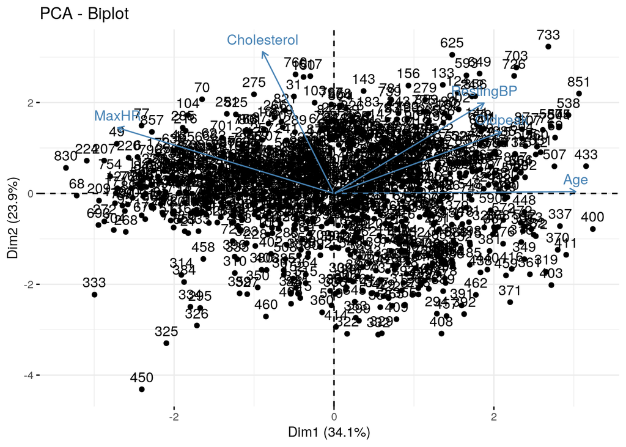

```r
# PC plot using fviz_pca
fviz_pca(pca1)
```

I ran a bar plot to give the different scores of each group. Using Eigen values and Kaiser’s rules, I chose to keep PC1 and PC2 because their eigen values were greater than 1. I plot these and found that ‘False’ values, indicating no heart disease in the group were lower that true values. From the values obtained in PCA analysis, it can be assumed that PC1 is a ‘Age’ vs ‘MaxHR’ axis, indicating that higher scores on PC1 mean a higher higher age value but a lower max heart rate. Finally, I ran a biplot with the fviz_pca function to visualize the PC scores in a different manner.

### Linear Classifier

```r
# linear classifier code here
fit <- glm(HeartDisease ~ Age + RestingBP + Cholesterol + MaxHR +
    Oldpeak, data = heart.df)
score <- predict(fit, type = "response")
score %>% round(3)
```

[output not shown]

```r
summary(fit$fitted.values)
```

```
##     Min.  1st Qu.   Median     Mean  3rd Qu.     Max.
## -0.02942  0.32595  0.53792  0.55338  0.77198  1.45286
```

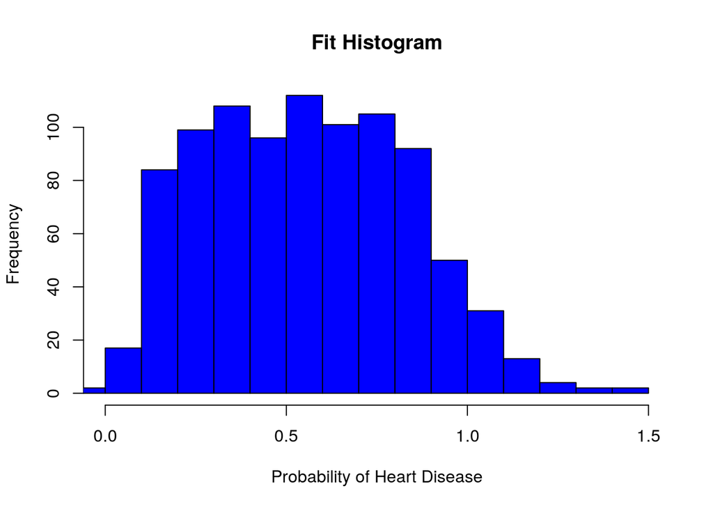

```r
# Histogram
hist(fit$fitted.values, main = "Fit Histogram", xlab = "Probability of Heart Disease",
    xlim = c(0, 1.5), col = "blue")
```

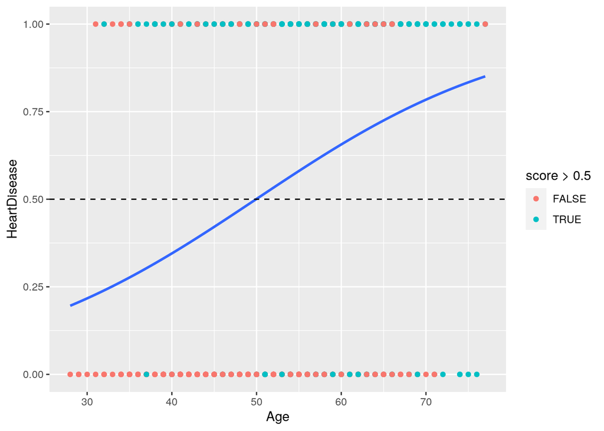

```r
# Logistic Regression
heart %>% mutate(score = score) %>% ggplot(aes(Age, HeartDisease)) +
    geom_point(aes(color = score > 0.5)) + geom_smooth(method = "glm",
    se = F, method.args = list(family = "binomial")) + ylim(0,
    1) + geom_hline(yintercept = 0.5, lty = 2)
```

```r
class_diag(score, truth = heart.df$HeartDisease, positive = 1)
```

```
##            acc   sens   spec    ppv     f1     ba    auc
## Metrics 0.7538 0.7815 0.7195 0.7754 0.7784 0.7505 0.8305
```

```r
# Table
probability <- predict(fit, type = "response")
probtable <- table(truth = heart.df$HeartDisease, prediction = as.numeric(probability >
    0.5)) %>% addmargins
colnames(probtable)[colnames(probtable) == "0"] = "Predicted No HD"
colnames(probtable)[colnames(probtable) == "1"] = "Predicted HD"
rownames(probtable)[rownames(probtable) == "0"] = "Observed No HD"
rownames(probtable)[rownames(probtable) == "1"] = "Observed HD"
probtable
```

```
##                 prediction
## truth            Predicted No HD Predicted HD Sum
##   Observed No HD             295          115 410
##   Observed HD                111          397 508
##   Sum                        406          512 918
```

```r
# cross-validation of linear classifier here
heartcv <- heart.df %>% mutate(HeartDisease = ifelse(HeartDisease ==
    "FAIL", 0, 1))
na.omit(heart.df)
```

[output not shown]

```r
keeps2 <- c("HeartDisease", "Age", "RestingBP", "Cholesterol",
    "MaxHR", "Oldpeak")
heartcv2 <- heart.df[keeps2]
set.seed(1234)
k = 10

data <- sample_frac(heartcv2)
folds <- rep(1:k, length.out = nrow(heartcv2))
diags <- NULL
i = 1
for (i in 1:k) {
    train <- data[folds != i, ]
    test <- data[folds == i, ]
    truth <- test$HeartDisease

    fit <- glm(HeartDisease ~ Age + RestingBP + Cholesterol +
        MaxHR + Oldpeak, data = heartcv2, family = "binomial")
    probs <- predict(fit, newdata = test, type = "response")
    diags <- rbind(diags, class_diag(probs, truth, positive = "True"))
}

# average performance metrics across all folds
summarize_all(diags, mean)
```

```
##       acc sens    spec ppv  f1  ba auc
## 1 0.43679  NaN 0.43679   0 NaN NaN   0
```

In my linear classifier, I created a logistic regression as well as a histogram to demonstrate predictions in if an individual would get heart disease. The logistic regression shows that at younger ages, there are more ‘FALSE’, predicting that there will be less susceptibility for heart disease. A table was created to compared predicted and observed values. The table showed that 71.9% of observed “No Heart Disease” values were predicted correct along with 78.1% of predicted Heart Disease in individuals being correct. These, along with an AUC score of 0.83 are very good and reflect a good prediction system. Furthermore, there seemed to be some trouble with performing the cross validation as a score of zero was produced.

### Non-Parametric Classifier

```r
library(caret)
# non-parametric classifier code here
knn_fit <- knn3(factor(HeartDisease == 1, levels = c("TRUE",
    "FALSE")) ~ Age + RestingBP + Cholesterol + MaxHR + Oldpeak,
    data = heart.df, k = 5)
y_hat_knn <- predict(knn_fit, heart.df)
table(truth = factor(heart.df$HeartDisease == 1, levels = c("TRUE",
    "FALSE")), prediction = factor(y_hat_knn[, 1] > 0.5, levels = c("TRUE",
    "FALSE"))) %>% addmargins
```

```
##        prediction
## truth   TRUE FALSE Sum
##   TRUE   412    96 508
##   FALSE  102   308 410
##   Sum    514   404 918
```

```r
class_diag(y_hat_knn[, 1], heart.df$HeartDisease, positive = 1)
```

```
##            acc  sens   spec    ppv     f1     ba    auc
## Metrics 0.7843 0.811 0.7512 0.8016 0.8063 0.7811 0.8689
```

```r
# cross-validation of np classifier here
heart.df1 <- heart.df %>% mutate(HeartDisease = ifelse(HeartDisease ==
    "No HD", 0, 1))
heart.df1$outcome <- NULL


set.seed(1234)
k = 10

data <- heart.df1[sample(nrow(heart.df1)), ]  #randomly order rows
folds <- cut(seq(1:nrow(heart.df1)), breaks = k, labels = F)  #create folds
diags <- NULL
for (i in 1:k) {
    ## Create training and test sets
    train <- data[folds != i, ]
    test <- data[folds == i, ]
    truth <- test$HeartDisease  ## Truth labels for fold i
    ## Train model on training set (all but fold i)
    fit1 <- knn3(HeartDisease == "True" ~ Age + RestingBP + Cholesterol +
        MaxHR + Oldpeak, data = train)
    ## Test model on test set (fold i)
    probs <- predict(fit1, newdata = test)
    ## Get diagnostics for fold i
    diags <- rbind(diags, class_diag(probs, truth, positive = 1))
}
summarize_all(diags, mean)
```

```
##   acc sens spec ppv f1  ba auc
## 1   1    1  NaN   1  1 NaN   1
```

I used K-nearest neighbors as my non-parametric classification method. Here, correct predictions of heart disease were 80.1% and correct predictions of no heart disease were 76.2%.Compared, to the linear classification model done previously, these scores were higher and thus prediction using this method can be considered to be more effective. Moreover, the AUC score produced was one of 0.87 which is desireable. However, when conducting the cross valudation, an AUC score of 1 was produced which is higher and indicates overfitting.

### Regression/Numeric Prediction

```r
# regression model code here
fit1 <- lm(Age ~ Cholesterol + MaxHR, data = heart.df)  #predict mpg from all other variables
yhat <- predict(fit1)  #predicted mpg

mean((heart.df$Age - yhat)^2)
```

```
## [1] 75.90242
```

```r
# cross-validation of regression model here
set.seed(1234)
k = 5  #choose number of folds
data <- heart.df[sample(nrow(heart.df)), ]  #randomly order rows
folds <- cut(seq(1:nrow(heart.df)), breaks = k, labels = F)  #create folds
diags <- NULL
for (i in 1:k) {
    train <- data[folds != i, ]
    test <- data[folds == i, ]
    ## Fit linear regression model to training set
    fit <- lm(Age ~ Cholesterol + MaxHR, data = train)
    ## Get predictions/y-hats on test set (fold i)
    yhat <- predict(fit, newdata = test)
    ## Compute prediction error (MSE) for fold i
    diags <- mean((test$Age - yhat)^2)
}
mean(diags)
```

```
## [1] 72.34745
```

The MSE value in the regression model is 75.9 and after cross validation it is 72.3. The MSE is lower in the Cross Validation which is good. If it were higher, that would be a significant sign of over fitting but because it is lower we can assume that there is no over fitting.

### Python

```r
library(reticulate)
use_python("/usr/bin/python3", required = F)
hi <- "I just..."

cat(c(hi, py$hi))
```

```
## I just...
```

```python
# python code here
bye = "GRADUATED!"
print(r.hi,bye)
```

```
## I just... GRADUATED!
```

Here, we used R to produce “I just…” when ‘hi’ was input. We did the same with Python, but produced “GRADUATED!” with the input ‘bye’. Put together the two were able to produce a sentence using both interfaces.

### Concluding Remarks

I truly enjoyed this class! Thank you for a wonderful semester.